# Trabalho Final

Alunas: Daniele …, Jessica Hemily de Sá Gonçalves, Larissa …

04/03/2024

### Pacotes

```r
library(psych)
library(summarytools)
library(performance)
library(MASS)
library(dplyr)
library(rstatix)
library(lmtest)
library(car)
library(ggpubr)
library(hnp)
library(nnet)
```

### Base de dados a ser analisada

```r
df <- read.csv('https://raw.githubusercontent.com/JessicaHemily/COMP_1/main/LeukocyteProfiles.csv/LeukocyteProfiles.csv',
                  header = TRUE,
                  sep = ',')

head(df)
```

```
##              Species FatScore BodyMass Heterophils Lymphocytes Eosinophils
## 1 Actitis hypoleucos        5       56          64          19           5
## 2 Actitis hypoleucos        1       44          60          34           0
## 3 Actitis hypoleucos        2       46          63          28           5
## 4 Actitis hypoleucos        3       47           2          87           4
## 5 Actitis hypoleucos        3       44          68          24           6
## 6 Actitis hypoleucos        5       45          42          45           6
##   Monocytes Basophils HLRatio
## 1         0        12    3.37
## 2         1         5    1.76
## 3         0         4    2.25
## 4         2         5    0.02
## 5         0         2    2.83
## 6         3         4    0.93
```

```r
#df_2 <- df[df$Species == "Calidris temminckii",]
#linha <- nrow(df_2)
#linha
```

### **1. Compreensão dos dados**

**VARIÁVEIS**

**FatScore:** Escore de gordura que varia de 0 a 8;

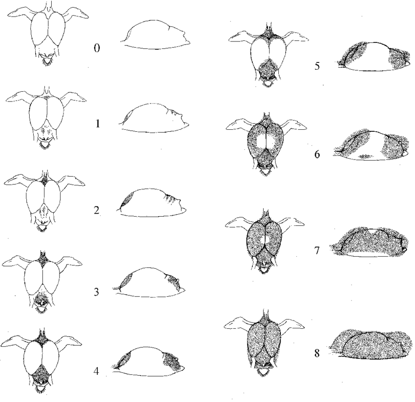

**BodyMass:** Massa do pássaro;

**Heterophils:** Heterófilos são fagócitos-chaves fundamentais para a defesa imunológica das aves. Eles se ligam e detectam patógenos invasores através do uso de receptores Toll-like (TLRs), receptores Fc e receptores de complemento;

**Lymphocytes:** Linfócitos são um tipo de leucócito ou glóbulo branco do sangue, responsáveis pelo reconhecimento e destruição de micro-organismos infecciosos como bactériase vírus;

**Eosinophils:** Os eosinófilos são um dos vários glóbulos brancos que sustentam o sistema imunológico e fazem parte do sistema de defesa do seu corpo contra alérgenos além de ajudar a protegê-lo contra infecções fúngicas e parasitárias. Comp: Dependendo da contagem de eosinófilos, a eosinofilia pode ser leve, moderada ou grave. Níveis elevados de eosinófilos podem indicar uma condição leve, como reação a medicamentos ou alergia, ou uma condição grave pode causar isso, incluindo algumas doenças do sangue. Um grande número de eosinófilos se aglomera em áreas específicas do corpo, causando problemas médicos ligados à inflamação que podem afetar várias áreas do corpo.

(https://my.clevelandclinic.org/health/diseases/17710-eosinophilia)

**Monocytes:** Os monócitos são um tipo de glóbulo branco do sistema imunológico, em que se transformam em macrófagos ou células dendríticas quando um germe ou bactéria invasora entra em seu corpo. As células matam o invasor ou alertam outras células sanguíneas para ajudar a destruí-lo e prevenir a infecção.

(https://my.clevelandclinic.org/health/body/22110-monocytes)

**Basophils:** Os basófilos são um tipo de glóbulo branco que trabalha em estreita colaboração com o sistema imunológico para defender o corpo contra alérgenos, patógenos e parasitas, em que liberam enzimas para melhorar o fluxo sanguíneo e prevenir coágulos sanguíneos.

(https://my.clevelandclinic.org/health/body/23256-basophils)

**HLRatio:** O HLRatio é geralmente considerada um indicador independente e robusto do nível de estresse em aves. Este parâmetro permite avaliar de forma simples a atividade do sistema imunológico e o estado de saúde individual de aves adultas e filhotes. Também permite avaliar a resposta do organismo ao estresse de curto e longo prazo induzido, entre outros, pelo ambiente envolvente, estresse social, parasitas sanguíneos ou um maior gasto energético das fêmeas durante a reprodução.

(https://bioone.org/journals/acta-ornithologica/volume-53/issue-2/00016454AO2018.53.2.001/Variation-of-Heterophil-to-Lymphocyte-Ratio-in-the-Great-Tit/10.3161/00016454AO2018.53.2.001.short#)

## Resumo dos Dados

```r
glimpse(df)
```

```
## Rows: 415
## Columns: 9
## $ Species     <chr> "Actitis hypoleucos", "Actitis hypoleucos", "Actitis hypol…
## $ FatScore    <int> 5, 1, 2, 3, 3, 5, 3, 3, 3, 3, 5, 5, 5, 4, 4, 6, 6, 4, 7, 7…
## $ BodyMass    <int> 56, 44, 46, 47, 44, 45, 44, 39, 44, 49, 61, 51, 60, 49, 48…
## $ Heterophils <int> 64, 60, 63, 2, 68, 42, 43, 40, 39, 67, 57, 22, 63, 77, 37,…
## $ Lymphocytes <int> 19, 34, 28, 87, 24, 45, 42, 37, 40, 25, 36, 61, 23, 22, 56…
## $ Eosinophils <int> 5, 0, 5, 4, 6, 6, 6, 5, 18, 2, 5, 6, 4, 1, 1, 4, 18, 6, 18…
## $ Monocytes   <int> 0, 1, 0, 2, 0, 3, 0, 1, 1, 3, 0, 1, 0, 0, 0, 3, 2, 2, 3, 1…
## $ Basophils   <int> 12, 5, 4, 5, 2, 4, 9, 17, 2, 3, 2, 10, 10, 0, 6, 5, 7, 4, …
## $ HLRatio     <dbl> 3.37, 1.76, 2.25, 0.02, 2.83, 0.93, 1.02, 1.08, 0.98, 2.68…
```

```r
summary(df)
```

```
##    Species             FatScore        BodyMass       Heterophils
##  Length:415         Min.   :0.000   Min.   : 20.00   Min.   : 1.00
##  Class :character   1st Qu.:0.000   1st Qu.: 45.00   1st Qu.:23.00
##  Mode  :character   Median :3.000   Median : 59.00   Median :35.00
##                     Mean   :2.701   Mean   : 76.03   Mean   :37.07
##                     3rd Qu.:5.000   3rd Qu.: 96.00   3rd Qu.:49.00
##                     Max.   :7.000   Max.   :236.00   Max.   :89.00
##                                     NA's   :3
##   Lymphocytes     Eosinophils       Monocytes        Basophils
##  Min.   : 7.00   Min.   : 0.000   Min.   :0.0000   Min.   : 0.000
##  1st Qu.:38.00   1st Qu.: 1.000   1st Qu.:0.0000   1st Qu.: 2.000
##  Median :53.00   Median : 3.000   Median :0.0000   Median : 4.000
##  Mean   :51.46   Mean   : 6.166   Mean   :0.9735   Mean   : 4.325
##  3rd Qu.:63.00   3rd Qu.: 9.000   3rd Qu.:2.0000   3rd Qu.: 6.000
##  Max.   :92.00   Max.   :45.000   Max.   :8.0000   Max.   :19.000
##
##     HLRatio
##  Min.   : 0.010
##  1st Qu.: 0.370
##  Median : 0.660
##  Mean   : 1.052
##  3rd Qu.: 1.195
##  Max.   :12.140
##
```

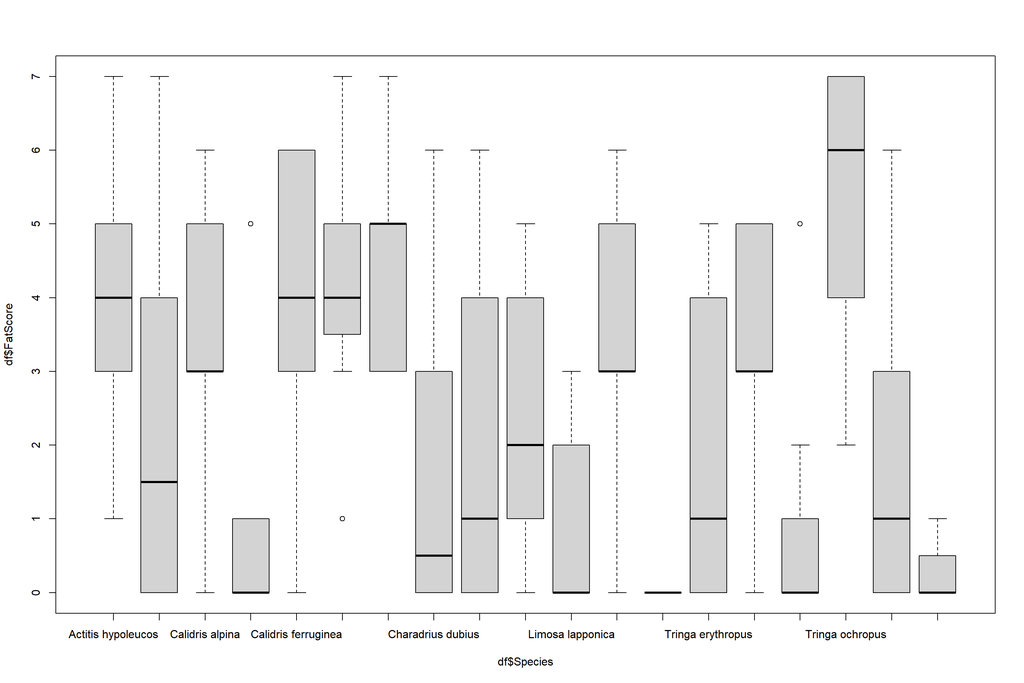

```r
boxplot(df$FatScore~df$Species)
```

### **2. Variável de Interesse**

A variável que se deseja modelar é a variável **discreta** FatScore.

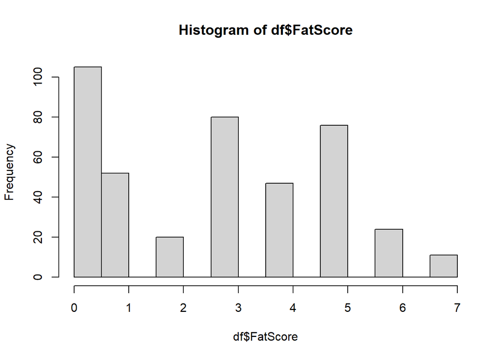

```r
hist(df$FatScore)
```

### Espécies e número de indíviduos

```r
cbind(table(df$Species))
```

```
##                      [,1]
## Actitis hypoleucos     22
## Arenaria interpres     32
## Calidris alpina        62
## Calidris canutus       10
## Calidris ferruginea    17
## Calidris minuta        23
## Calidris temminckii     5
## Charadrius dubius      28
## Charadrius hiaticula   34
## Limicola falcinellus   11
## Limosa lapponica        9
## Philomachus pugnax     36
## Pluvialis squatarola    5
## Tringa erythropus      20
## Tringa glareola        38
## Tringa nebularia        7
## Tringa ochropus         7
## Tringa totanus         42
## Vanellus vanellus       7
```

```r
n_species <- length(cbind(table(df$Species)))

cat("A base de dados apresenta ",n_species, " espécies distintas")
```

```
## A base de dados apresenta  19  espécies distintas
```

### Outliers

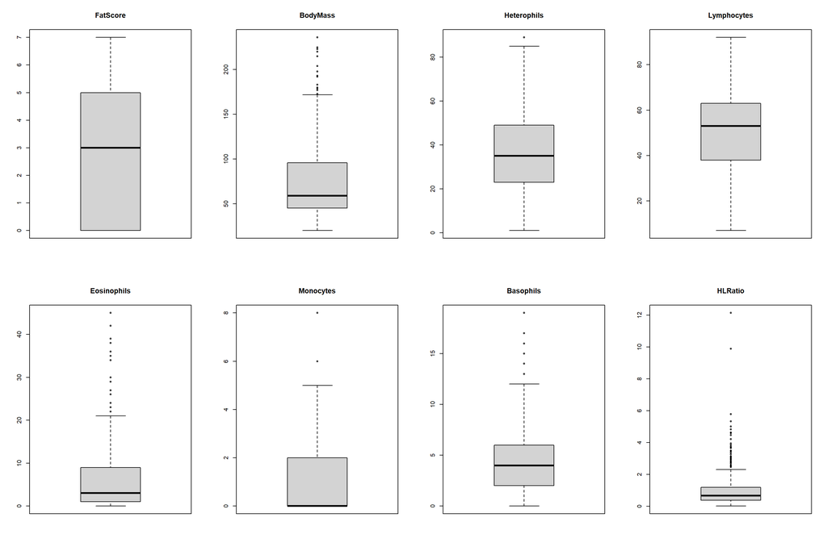

```r
par(mfrow = c(2,4))
for (coluna in c(2:9)) {
  variavel <- names(df)[coluna]
  boxplot(df[,coluna],main = variavel)
}
```

Devido as diferentes espécies em estudo, é esperado que haja variabilidade dos dados.

### Levantamento de idéias

- A variável resposta é do tipo discreta;
- Descartamos a regressão linear lm(), devido a variável resposta não ser contínua;
- Talvez seja interessante agregar o gênero da variável “Species” (retirar a espécie da nomenclatura binomial) para a criação do moledo.

### Criar a variável “Genero” apartir da “Species”

```r
# Função para extrair a primeira palavra de uma string
extrair_primeira_palavra <- function(string) {
  palavras <- strsplit(string, " ")[[1]]
  primeira_palavra <- palavras[1]
  return(primeira_palavra)
}

df$Genero <- sapply(df$Species, extrair_primeira_palavra)
```

### Genero e número de indíviduos

```r
cbind(table(df$Genero))
```

```
##             [,1]
## Actitis       22
## Arenaria      32
## Calidris     117
## Charadrius    62
## Limicola      11
## Limosa         9
## Philomachus   36
## Pluvialis      5
## Tringa       114
## Vanellus       7
```

```r
n_genero <- length(cbind(table(df$Genero)))

cat("Existem ",n_genero," Gêneros distintos")
```

```
## Existem  10  Gêneros distintos
```

### Outliers

Criação de boxplot por genero

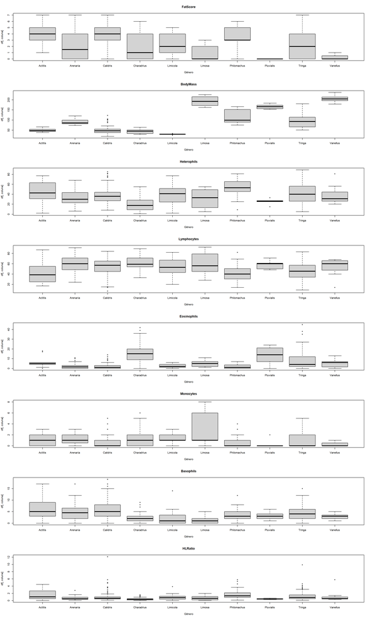

```r
par(mfrow = c(8,1))
for (coluna in c(2:9)) {
  variavel <- names(df)[coluna]
  boxplot(df[,coluna] ~df[,10],main = variavel, xlab = "Gênero")
}
```

Considerando o tamanho da base de dados, considera-se que haja poucos outliers (**subjetivamente**).

### **3. NAs na base?**

```r
df_na <- df[!complete.cases(df),]
head(df_na)
```

```
##                 Species FatScore BodyMass Heterophils Lymphocytes Eosinophils
## 170 Calidris temminckii        7       NA          62          34           0
## 288  Philomachus pugnax        3       NA          74          22           2
## 377      Tringa totanus        6       NA          17          62          16
##     Monocytes Basophils HLRatio      Genero
## 170         0         4    1.82    Calidris
## 288         0         2    3.36 Philomachus
## 377         0         5    0.27      Tringa
```

```r
linhas_na <- nrow(df_na)
linhas_df <- nrow(df)
linhas_na
```

```
## [1] 3
```

```r
cat("A base de dados possui",linhas_df, "observacoes e",linhas_na, "linhas contendo ao menos um NA")
```

```
## A base de dados possui 415 observacoes e 3 linhas contendo ao menos um NA
```

### Identificar as variáveis que possuem NAs

```r
cbind(colSums(is.na(df)))
```

```
##             [,1]
## Species        0
## FatScore       0
## BodyMass       3
## Heterophils    0
## Lymphocytes    0
## Eosinophils    0
## Monocytes      0
## Basophils      0
## HLRatio        0
## Genero         0
```

### Cálculo da mediana de bodymass para substituição dos valore NAs

```r
#median_bm <- median(df$BodyMass,by(df$Species_2),na.rm = TRUE)
#median_bm

# Função para substituir os valores NA pela mediana, agrupada pelo Genero
substituir_na_pela_mediana <- function(valor) {
  mediana <- median(valor, na.rm = TRUE)
  valor[is.na(valor)] <- mediana
  return(valor)
}
```

### Substituir os NAs pela mediana

```r
#df$BodyMass <- (replace(x = df$BodyMass,
 #                              list = is.na(df$BodyMass),
  #                             values = median_bm)
   #                             )

#Substituição levando em consideração o Genero
df$BodyMass <- ave(df$BodyMass, df$Genero, FUN = substituir_na_pela_mediana)
```

### **4. Há multicolinearidade entre as variáveis preditoras?**

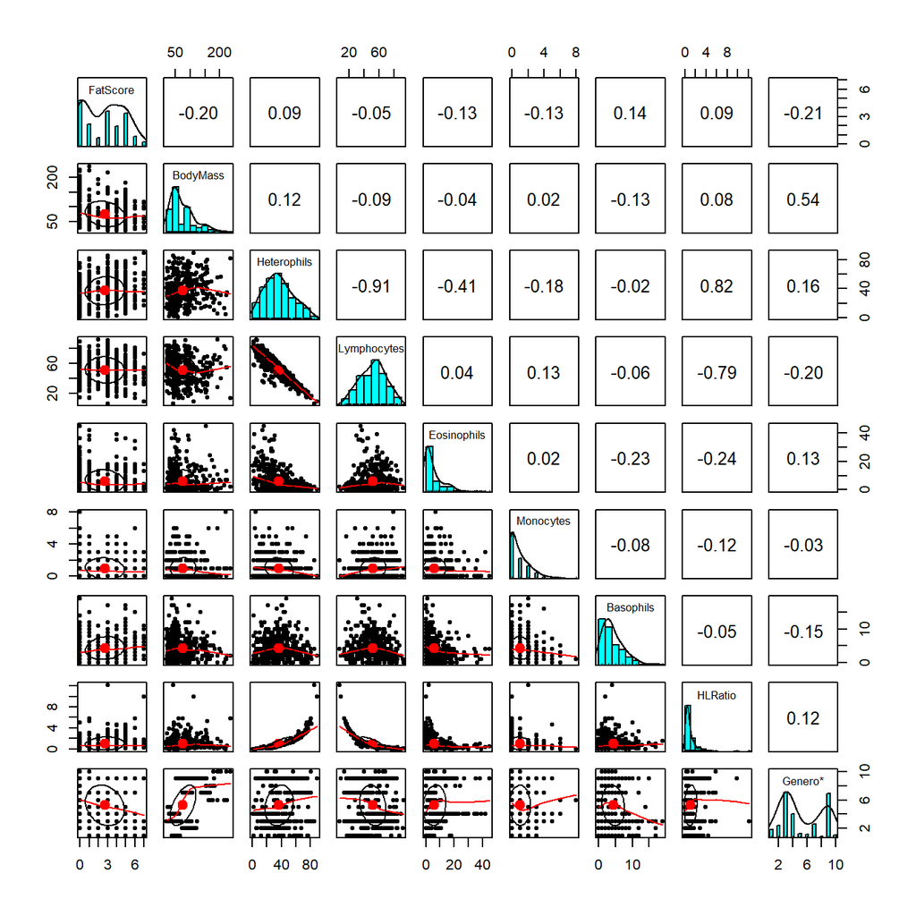

```r
pairs.panels(df[,-1])
```

### **5. Criação do Modelo**

### 1° Modelo - GLM

- Sem incluir as variáveis “Lymphocytis” e “HLRatio” na criação do modelo

```r
modelo <- glm(FatScore ~ BodyMass + Heterophils + Eosinophils + Monocytes + Basophils + Genero, data = df)
modelo
```

```
##
## Call:  glm(formula = FatScore ~ BodyMass + Heterophils + Eosinophils +
##     Monocytes + Basophils + Genero, data = df)
##
## Coefficients:
##       (Intercept)           BodyMass        Heterophils        Eosinophils
##         4.4611692         -0.0025119         -0.0017411          0.0135656
##         Monocytes          Basophils     GeneroArenaria     GeneroCalidris
##        -0.1165717          0.0005626         -1.7380442         -0.5720606
##  GeneroCharadrius     GeneroLimicola       GeneroLimosa  GeneroPhilomachus
##        -2.6268792         -1.9320337         -2.8969438         -0.7857879
##   GeneroPluvialis       GeneroTringa     GeneroVanellus
##        -4.1340451         -1.8055681         -3.6303105
##
## Degrees of Freedom: 414 Total (i.e. Null);  400 Residual
## Null Deviance:       1879
## Residual Deviance: 1510  AIC: 1746
```

As variáveis “Lymphocytis” e “HLRatio” não foram incluídas no modelo devido menor relação com a variável resposta.

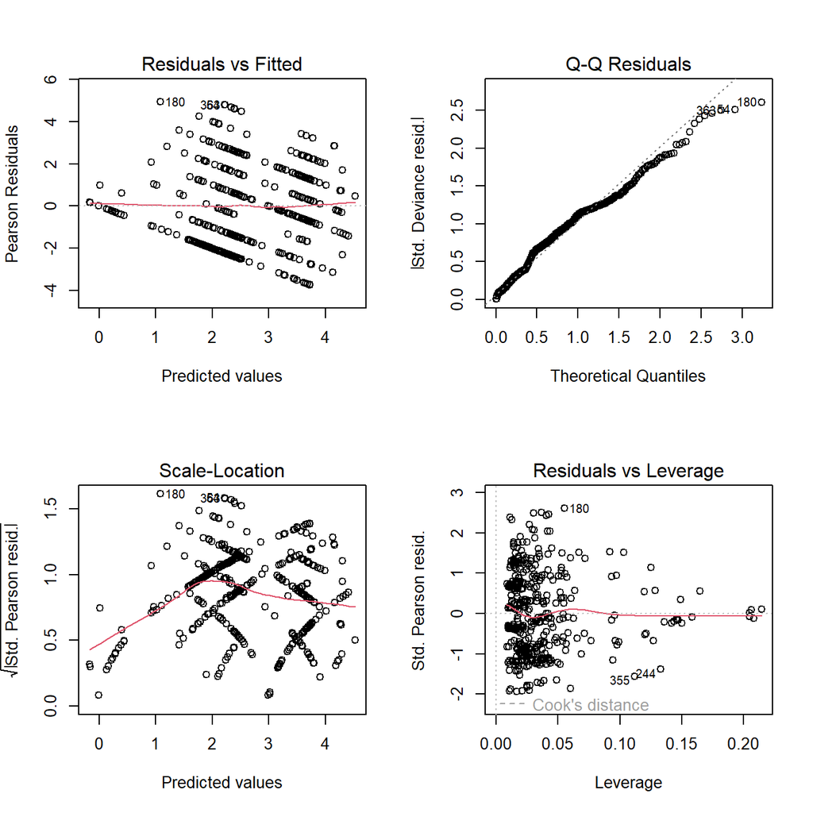

```r
par(mfrow = c(2,2))
plot(modelo)
```

#### Resíduos

```
## Half-normal plot with simulated envelope generated assuming the residuals are
##         normally distributed under the null hypothesis.
```

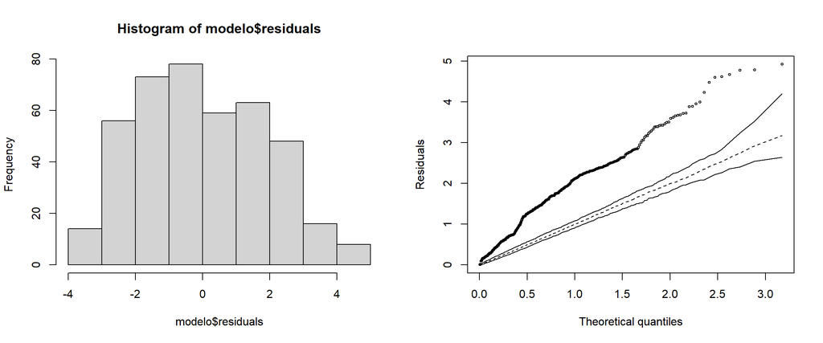

```r
par(mfrow = c(1,2))
hist(modelo$residuals)
hnp::hnp(modelo$residuals)
```

### 2° Modelo - GLM

- Sem incluir as variáveis “Lymphocytis” e “Heterophils” na criação do modelo

```r
modelo <- glm(FatScore ~ BodyMass + HLRatio + Eosinophils + Monocytes + Basophils + Genero, data = df)
modelo
```

```
##
## Call:  glm(formula = FatScore ~ BodyMass + HLRatio + Eosinophils + Monocytes +
##     Basophils + Genero, data = df)
##
## Coefficients:
##       (Intercept)           BodyMass            HLRatio        Eosinophils
##          4.239032          -0.002444           0.054108           0.017245
##         Monocytes          Basophils     GeneroArenaria     GeneroCalidris
##         -0.107604           0.004565          -1.655412          -0.509831
##  GeneroCharadrius     GeneroLimicola       GeneroLimosa  GeneroPhilomachus
##         -2.545361          -1.870356          -2.828739          -0.787464
##   GeneroPluvialis       GeneroTringa     GeneroVanellus
##         -4.056435          -1.782922          -3.595365
##
## Degrees of Freedom: 414 Total (i.e. Null);  400 Residual
## Null Deviance:       1879
## Residual Deviance: 1509  AIC: 1745
```

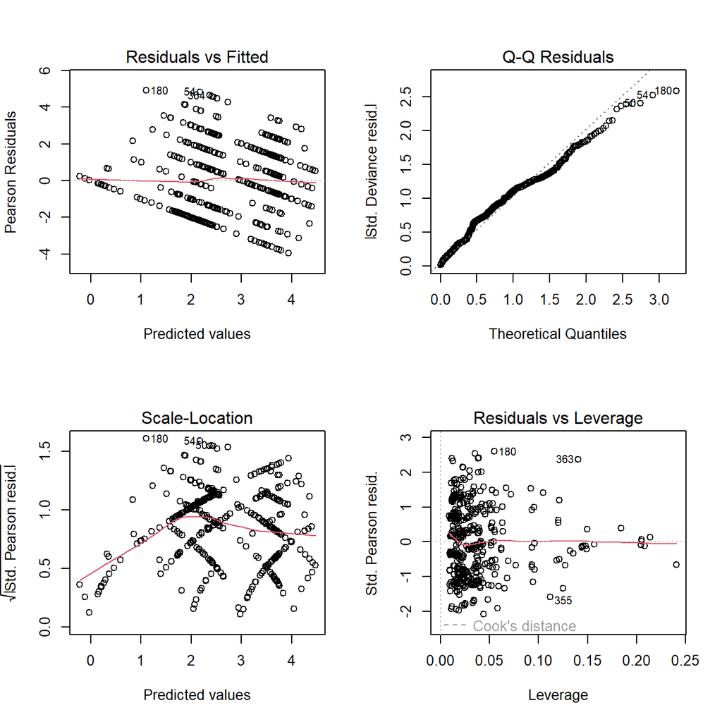

```r
par(mfrow = c(2,2))
plot(modelo)
```

#### Resíduos

```
## Half-normal plot with simulated envelope generated assuming the residuals are
##         normally distributed under the null hypothesis.
```

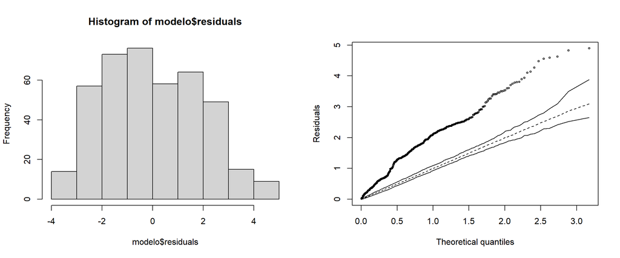

```r
par(mfrow = c(1,2))
hist(modelo$residuals)
hnp::hnp(modelo$residuals)
```

#### Procurar por outros modelos

```r
step(modelo)
```

```
## Start:  AIC=1745.41
## FatScore ~ BodyMass + HLRatio + Eosinophils + Monocytes + Basophils +
##     Genero
##
##               Df Deviance    AIC
## - Basophils    1   1508.9 1743.4
## - BodyMass     1   1510.1 1743.7
## - HLRatio      1   1510.4 1743.8
## - Eosinophils  1   1513.3 1744.7
## <none>             1508.8 1745.4
## - Monocytes    1   1516.4 1745.5
## - Genero       9   1716.1 1780.8
##
## Step:  AIC=1743.43
## FatScore ~ BodyMass + HLRatio + Eosinophils + Monocytes + Genero
##
##               Df Deviance    AIC
## - BodyMass     1   1510.1 1741.8
## - HLRatio      1   1510.4 1741.8
## - Eosinophils  1   1513.3 1742.7
## <none>             1508.9 1743.4
## - Monocytes    1   1516.6 1743.5
## - Genero       9   1728.4 1781.8
##
## Step:  AIC=1741.77
## FatScore ~ HLRatio + Eosinophils + Monocytes + Genero
##
##               Df Deviance    AIC
## - HLRatio      1   1511.7 1740.2
## - Eosinophils  1   1514.5 1741.0
## <none>             1510.1 1741.8
## - Monocytes    1   1517.8 1741.9
## - Genero       9   1812.4 1799.5
##
## Step:  AIC=1740.2
## FatScore ~ Eosinophils + Monocytes + Genero
##
##               Df Deviance    AIC
## - Eosinophils  1   1515.2 1739.2
## <none>             1511.7 1740.2
## - Monocytes    1   1520.1 1740.5
## - Genero       9   1816.1 1798.3
##
## Step:  AIC=1739.16
## FatScore ~ Monocytes + Genero
##
##             Df Deviance    AIC
## <none>           1515.2 1739.2
## - Monocytes  1   1524.3 1739.6
## - Genero     9   1848.0 1803.5
```

```
##
## Call:  glm(formula = FatScore ~ Monocytes + Genero, data = df)
##
## Coefficients:
##       (Intercept)          Monocytes     GeneroArenaria     GeneroCalidris
##            4.3493            -0.1167            -1.8763            -0.6179
##  GeneroCharadrius     GeneroLimicola       GeneroLimosa  GeneroPhilomachus
##           -2.4406            -1.9280            -3.2473            -1.0312
##   GeneroPluvialis       GeneroTringa     GeneroVanellus
##           -4.3026            -1.8935            -4.0302
##
## Degrees of Freedom: 414 Total (i.e. Null);  404 Residual
## Null Deviance:       1879
## Residual Deviance: 1515  AIC: 1739
```

```r
#hist(modelo$residuals)

#summary(modelo)

#anova(modelo)

#AIC(modelo)
```

### 3° Modelo - GLM

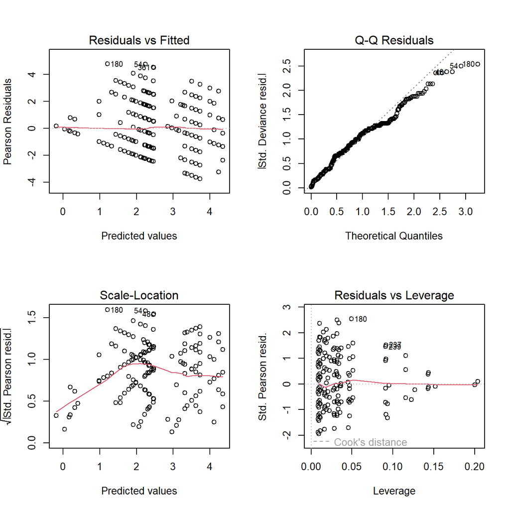

```r
modelo <- glm(formula = FatScore ~ Monocytes + Genero, data = df)

par(mfrow=c(2,2))
plot(modelo)
```

```
## Half-normal plot with simulated envelope generated assuming the residuals are
##         normally distributed under the null hypothesis.
```

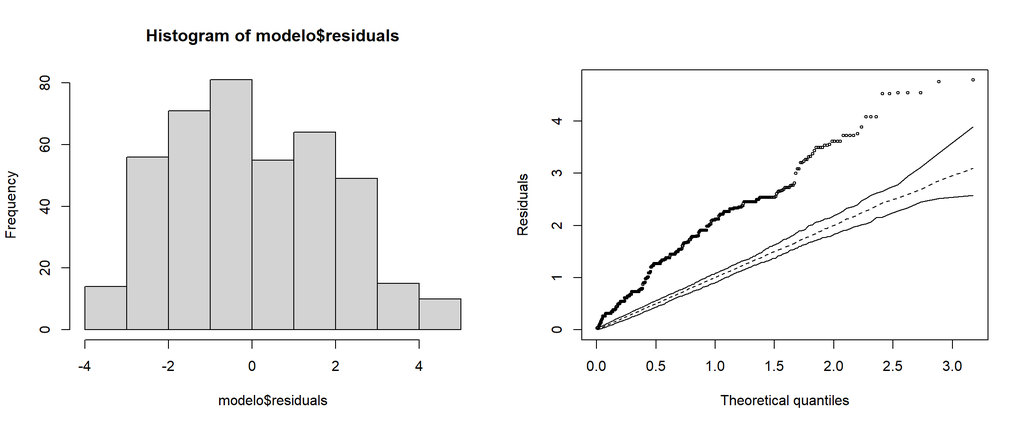

```r
par(mfrow = c(1,2))
hist(modelo$residuals)
hnp::hnp(modelo$residuals)
```

### 4° Modelo - GLM - Poisson

```r
# Ajustando um modelo de regressão de Poisson
#df <- df[c(-28,-82,-56),]
modelo <- glm(FatScore ~ BodyMass + Heterophils + Eosinophils + Monocytes + Basophils + Genero, data = df, family = poisson)

# Visualizando os resultados
summary(modelo)
```

```
##
## Call:
## glm(formula = FatScore ~ BodyMass + Heterophils + Eosinophils +
##     Monocytes + Basophils + Genero, family = poisson, data = df)
##
## Coefficients:
##                     Estimate Std. Error z value Pr(>|z|)
## (Intercept)        1.527e+00  1.806e-01   8.457  < 2e-16 ***
## BodyMass          -9.033e-04  1.343e-03  -0.673 0.501172
## Heterophils       -6.660e-04  1.859e-03  -0.358 0.720121
## Eosinophils        5.959e-03  5.463e-03   1.091 0.275366
## Monocytes         -5.192e-02  2.684e-02  -1.934 0.053055 .
## Basophils          5.137e-04  9.262e-03   0.055 0.955773
## GeneroArenaria    -5.320e-01  1.703e-01  -3.124 0.001782 **
## GeneroCalidris    -1.436e-01  1.202e-01  -1.194 0.232326
## GeneroCharadrius  -9.453e-01  1.559e-01  -6.062 1.34e-09 ***
## GeneroLimicola    -6.048e-01  2.305e-01  -2.624 0.008699 **
## GeneroLimosa      -1.484e+00  4.396e-01  -3.375 0.000738 ***
## GeneroPhilomachus -1.925e-01  1.697e-01  -1.135 0.256584
## GeneroPluvialis   -1.672e+01  5.700e+02  -0.029 0.976595
## GeneroTringa      -5.664e-01  1.350e-01  -4.196 2.72e-05 ***
## GeneroVanellus    -2.587e+00  7.454e-01  -3.471 0.000518 ***
## ---
## Signif. codes:  0 '***' 0.001 '**' 0.01 '*' 0.05 '.' 0.1 ' ' 1
##
## (Dispersion parameter for poisson family taken to be 1)
##
##     Null deviance: 915.03  on 414  degrees of freedom
## Residual deviance: 753.18  on 400  degrees of freedom
## AIC: 1726.5
##
## Number of Fisher Scoring iterations: 13
```

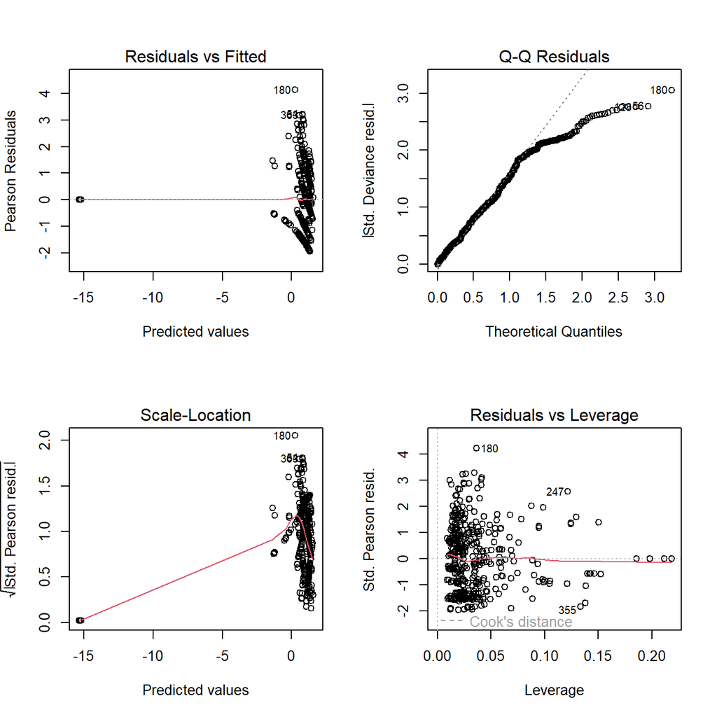

```r
par(mfrow=c(2,2))
plot(modelo)
```

```
## Half-normal plot with simulated envelope generated assuming the residuals are
##         normally distributed under the null hypothesis.
```

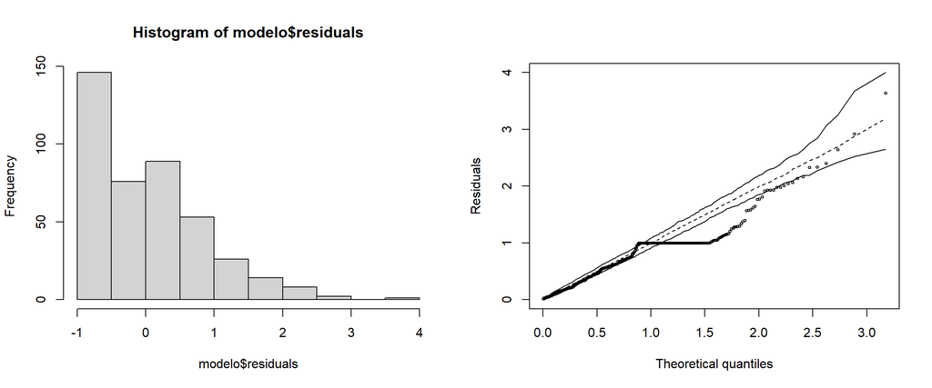

```r
par(mfrow = c(1,2))
hist(modelo$residuals)
hnp::hnp(modelo$residuals)
```

### 5° Modelo - GLM - Gaussian

```r
# Ajustando um modelo de regressão de Poisson
#df <- df[c(-28,-82,-56),]
modelo <- glm(FatScore ~ BodyMass + Heterophils + Eosinophils + Monocytes + Basophils + Species , data = df, family = gaussian())

# Visualizando os resultados
summary(modelo)
```

```
##
## Call:
## glm(formula = FatScore ~ BodyMass + Heterophils + Eosinophils +
##     Monocytes + Basophils + Species, family = gaussian(), data = df)
##
## Coefficients:
##                               Estimate Std. Error t value Pr(>|t|)
## (Intercept)                   2.029300   0.628372   3.229 0.001345 **
## BodyMass                      0.046765   0.006698   6.982 1.26e-11 ***
## Heterophils                  -0.003683   0.005423  -0.679 0.497478
## Eosinophils                   0.015429   0.014855   1.039 0.299624
## Monocytes                    -0.022266   0.069025  -0.323 0.747188
## Basophils                    -0.005014   0.028640  -0.175 0.861120
## SpeciesArenaria interpres    -3.813200   0.561736  -6.788 4.23e-11 ***
## SpeciesCalidris alpina       -0.571692   0.438644  -1.303 0.193234
## SpeciesCalidris canutus      -5.425745   0.753668  -7.199 3.13e-12 ***
## SpeciesCalidris ferruginea   -0.126786   0.566875  -0.224 0.823140
## SpeciesCalidris minuta        1.245106   0.554371   2.246 0.025263 *
## SpeciesCalidris temminckii    1.448039   0.871752   1.661 0.097501 .
## SpeciesCharadrius dubius     -2.061806   0.527766  -3.907 0.000110 ***
## SpeciesCharadrius hiaticula  -2.759608   0.518041  -5.327 1.69e-07 ***
## SpeciesLimicola falcinellus  -1.010210   0.659495  -1.532 0.126382
## SpeciesLimosa lapponica     -10.102866   1.189441  -8.494 4.23e-16 ***
## SpeciesPhilomachus pugnax    -4.056649   0.657840  -6.167 1.74e-09 ***
## SpeciesPluvialis squatarola  -9.887459   1.160457  -8.520 3.49e-16 ***
## SpeciesTringa erythropus     -6.425553   0.775886  -8.282 1.95e-15 ***
## SpeciesTringa glareola       -1.696372   0.471510  -3.598 0.000362 ***
## SpeciesTringa nebularia      -7.745612   0.989170  -7.830 4.62e-14 ***
## SpeciesTringa ochropus       -0.830282   0.805980  -1.030 0.303576
## SpeciesTringa totanus        -4.836227   0.554447  -8.723  < 2e-16 ***
## SpeciesVanellus vanellus    -11.252018   1.284141  -8.762  < 2e-16 ***
## ---
## Signif. codes:  0 '***' 0.001 '**' 0.01 '*' 0.05 '.' 0.1 ' ' 1
##
## (Dispersion parameter for gaussian family taken to be 2.960304)
##
##     Null deviance: 1878.9  on 414  degrees of freedom
## Residual deviance: 1157.5  on 391  degrees of freedom
## AIC: 1653.4
##
## Number of Fisher Scoring iterations: 2
```

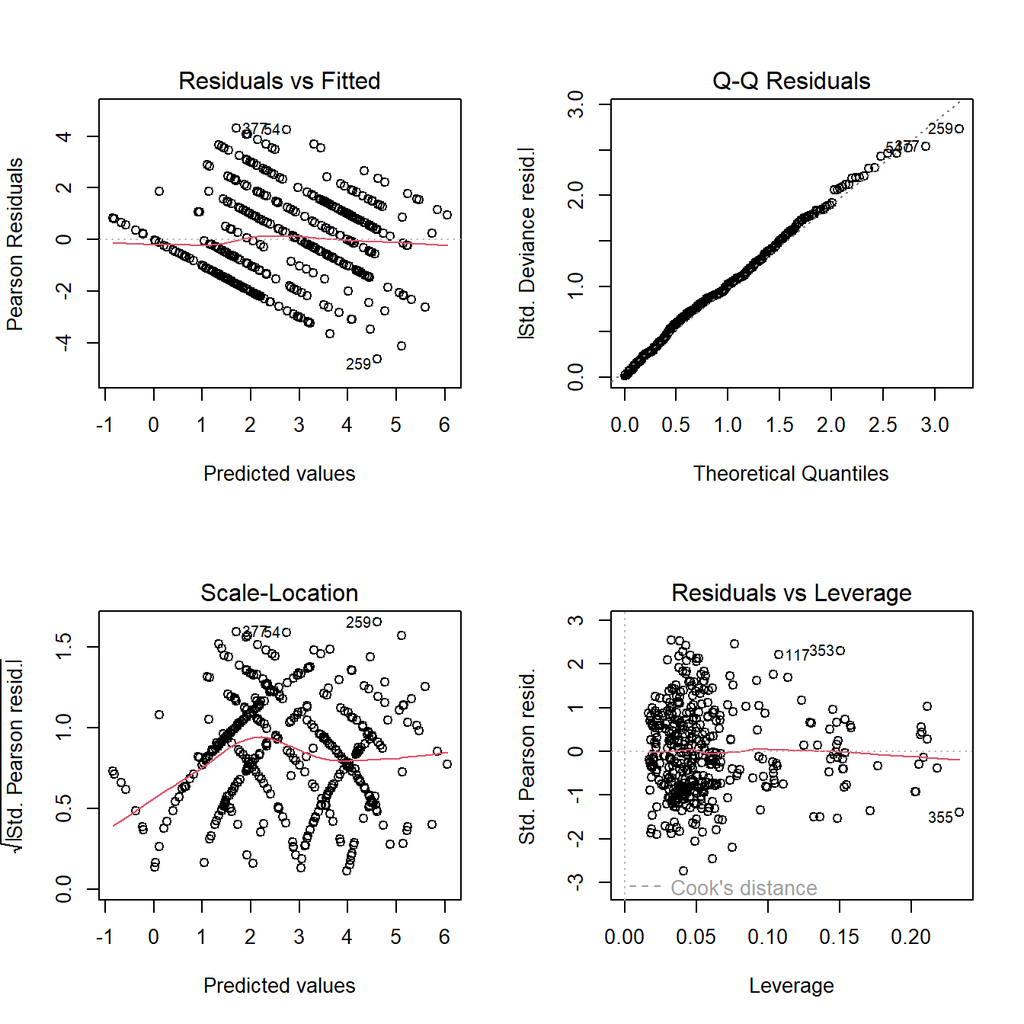

```r
par(mfrow=c(2,2))
plot(modelo)
```

```
## Half-normal plot with simulated envelope generated assuming the residuals are
##         normally distributed under the null hypothesis.
```

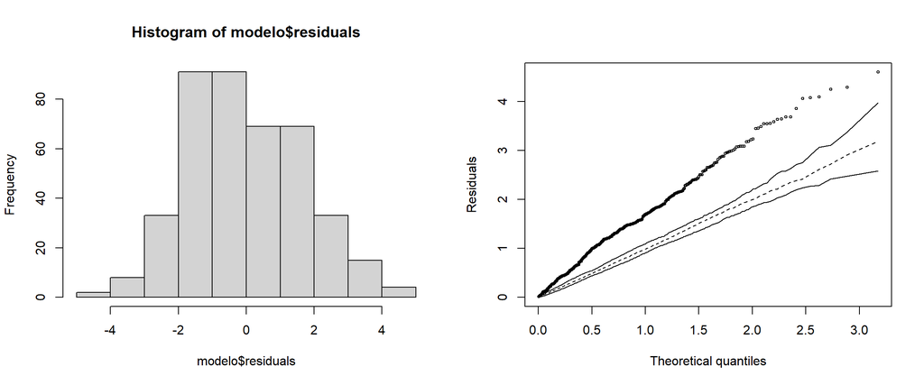

```r
par(mfrow = c(1,2))
hist(modelo$residuals)
hnp::hnp(modelo$residuals)
```

### 6° Modelo - TESTE NEGATIVE BINOMIAL

```r
modelo <- glm.nb(FatScore ~ BodyMass + Heterophils + Eosinophils + Monocytes + Basophils + Species, data = df)

summary(modelo)
```

```
##
## Call:
## glm.nb(formula = FatScore ~ BodyMass + Heterophils + Eosinophils +
##     Monocytes + Basophils + Species, data = df, init.theta = 25.65015932,
##     link = log)
##
## Coefficients:
##                               Estimate Std. Error z value Pr(>|z|)
## (Intercept)                  6.051e-01  2.235e-01   2.707 0.006793 **
## BodyMass                     1.720e-02  2.517e-03   6.834 8.25e-12 ***
## Heterophils                 -1.380e-03  2.018e-03  -0.684 0.494124
## Eosinophils                  7.886e-03  6.150e-03   1.282 0.199741
## Monocytes                   -7.980e-03  2.856e-02  -0.279 0.779900
## Basophils                   -1.507e-03  1.035e-02  -0.146 0.884260
## SpeciesArenaria interpres   -1.309e+00  2.021e-01  -6.473 9.60e-11 ***
## SpeciesCalidris alpina      -1.196e-01  1.404e-01  -0.852 0.394187
## SpeciesCalidris canutus     -2.144e+00  3.477e-01  -6.167 6.98e-10 ***
## SpeciesCalidris ferruginea  -4.880e-02  1.753e-01  -0.278 0.780675
## SpeciesCalidris minuta       4.573e-01  1.759e-01   2.600 0.009320 **
## SpeciesCalidris temminckii   4.911e-01  2.628e-01   1.868 0.061714 .
## SpeciesCharadrius dubius    -7.621e-01  2.025e-01  -3.763 0.000168 ***
## SpeciesCharadrius hiaticula -9.933e-01  1.915e-01  -5.187 2.14e-07 ***
## SpeciesLimicola falcinellus -2.532e-01  2.465e-01  -1.027 0.304397
## SpeciesLimosa lapponica     -4.204e+00  5.590e-01  -7.521 5.45e-14 ***
## SpeciesPhilomachus pugnax   -1.485e+00  2.571e-01  -5.776 7.67e-09 ***
## SpeciesPluvialis squatarola -4.057e+01  3.001e+07   0.000 0.999999
## SpeciesTringa erythropus    -2.365e+00  3.032e-01  -7.800 6.21e-15 ***
## SpeciesTringa glareola      -5.250e-01  1.533e-01  -3.424 0.000617 ***
## SpeciesTringa nebularia     -3.126e+00  4.712e-01  -6.633 3.28e-11 ***
## SpeciesTringa ochropus      -4.833e-01  2.439e-01  -1.982 0.047521 *
## SpeciesTringa totanus       -1.790e+00  2.078e-01  -8.617  < 2e-16 ***
## SpeciesVanellus vanellus    -5.414e+00  8.267e-01  -6.550 5.77e-11 ***
## ---
## Signif. codes:  0 '***' 0.001 '**' 0.01 '*' 0.05 '.' 0.1 ' ' 1
##
## (Dispersion parameter for Negative Binomial(25.6502) family taken to be 1)
##
##     Null deviance: 848.83  on 414  degrees of freedom
## Residual deviance: 582.84  on 391  degrees of freedom
## AIC: 1616.8
##
## Number of Fisher Scoring iterations: 1
##
##
##               Theta:  25.7
##           Std. Err.:  24.4
##
##  2 x log-likelihood:  -1566.767
```

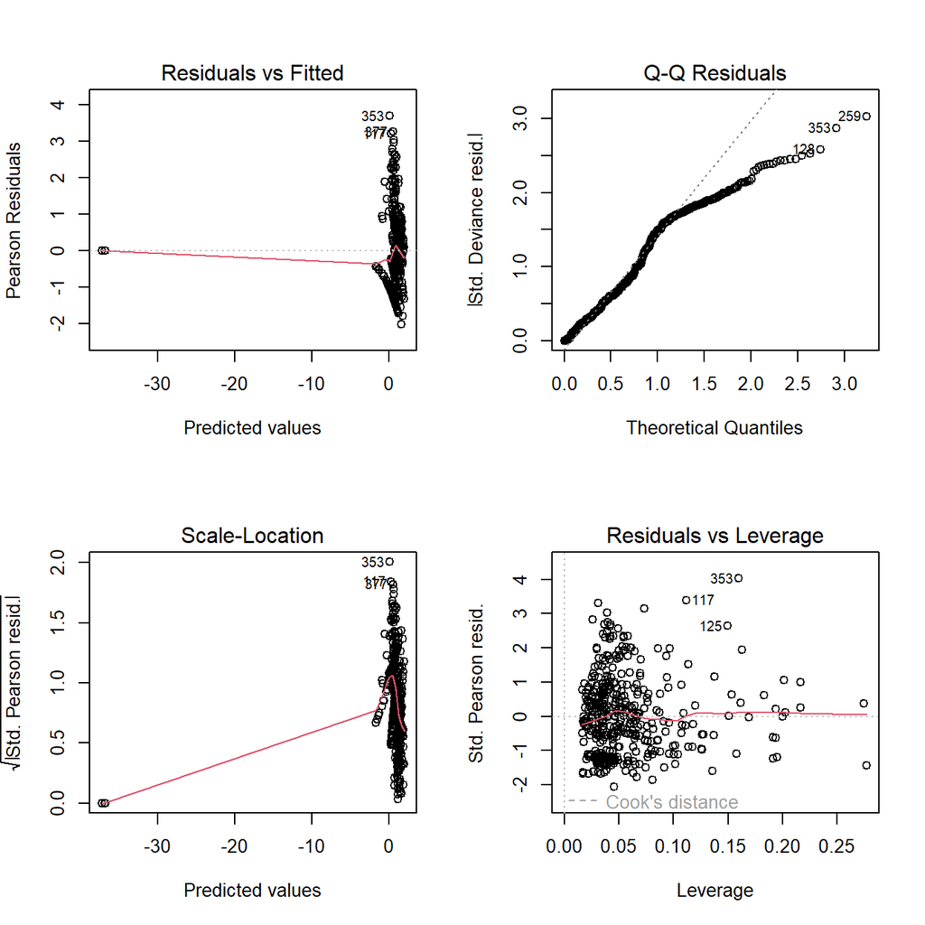

```r
par(mfrow=c(2,2))
plot(modelo)
```

```
## Half-normal plot with simulated envelope generated assuming the residuals are
##         normally distributed under the null hypothesis.
```

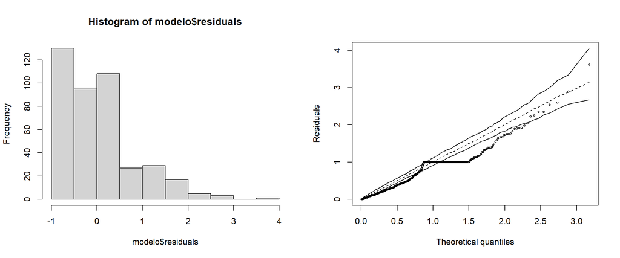

```r
par(mfrow = c(1,2))
hist(modelo$residuals)
hnp::hnp(modelo$residuals)
```

### 7° Modelo - Ajustando um Modelo de Regressão de Poisson Quase (QPR):

```r
modelo <- glm(FatScore ~ BodyMass + Heterophils + Eosinophils + Monocytes + Basophils + Species, data = df, family = quasipoisson())

summary(modelo)
```

```
##
## Call:
## glm(formula = FatScore ~ BodyMass + Heterophils + Eosinophils +
##     Monocytes + Basophils + Species, family = quasipoisson(),
##     data = df)
##
## Coefficients:
##                               Estimate Std. Error t value Pr(>|t|)
## (Intercept)                   0.613730   0.247182   2.483 0.013450 *
## BodyMass                      0.016996   0.002810   6.047 3.45e-09 ***
## Heterophils                  -0.001342   0.002229  -0.602 0.547490
## Eosinophils                   0.007881   0.006865   1.148 0.251720
## Monocytes                    -0.006297   0.031819  -0.198 0.843214
## Basophils                    -0.001367   0.011428  -0.120 0.904870
## SpeciesArenaria interpres    -1.295026   0.224025  -5.781 1.52e-08 ***
## SpeciesCalidris alpina       -0.118593   0.153369  -0.773 0.439838
## SpeciesCalidris canutus      -2.126953   0.393505  -5.405 1.13e-07 ***
## SpeciesCalidris ferruginea   -0.046029   0.190550  -0.242 0.809247
## SpeciesCalidris minuta        0.451910   0.192102   2.352 0.019145 *
## SpeciesCalidris temminckii    0.486656   0.284455   1.711 0.087905 .
## SpeciesCharadrius dubius     -0.763145   0.226155  -3.374 0.000814 ***
## SpeciesCharadrius hiaticula  -0.990281   0.212681  -4.656 4.42e-06 ***
## SpeciesLimicola falcinellus  -0.259323   0.275213  -0.942 0.346641
## SpeciesLimosa lapponica      -4.179452   0.633900  -6.593 1.40e-10 ***
## SpeciesPhilomachus pugnax    -1.504015   0.288553  -5.212 3.03e-07 ***
## SpeciesPluvialis squatarola -18.812901 666.781272  -0.028 0.977505
## SpeciesTringa erythropus     -2.344170   0.339088  -6.913 1.94e-11 ***
## SpeciesTringa glareola       -0.522634   0.167966  -3.112 0.001998 **
## SpeciesTringa nebularia      -3.108081   0.536027  -5.798 1.38e-08 ***
## SpeciesTringa ochropus       -0.471428   0.263838  -1.787 0.074743 .
## SpeciesTringa totanus        -1.778109   0.231335  -7.686 1.24e-13 ***
## SpeciesVanellus vanellus     -5.377925   0.952109  -5.648 3.12e-08 ***
## ---
## Signif. codes:  0 '***' 0.001 '**' 0.01 '*' 0.05 '.' 0.1 ' ' 1
##
## (Dispersion parameter for quasipoisson family taken to be 1.378446)
##
##     Null deviance: 915.03  on 414  degrees of freedom
## Residual deviance: 624.59  on 391  degrees of freedom
## AIC: NA
##
## Number of Fisher Scoring iterations: 13
```

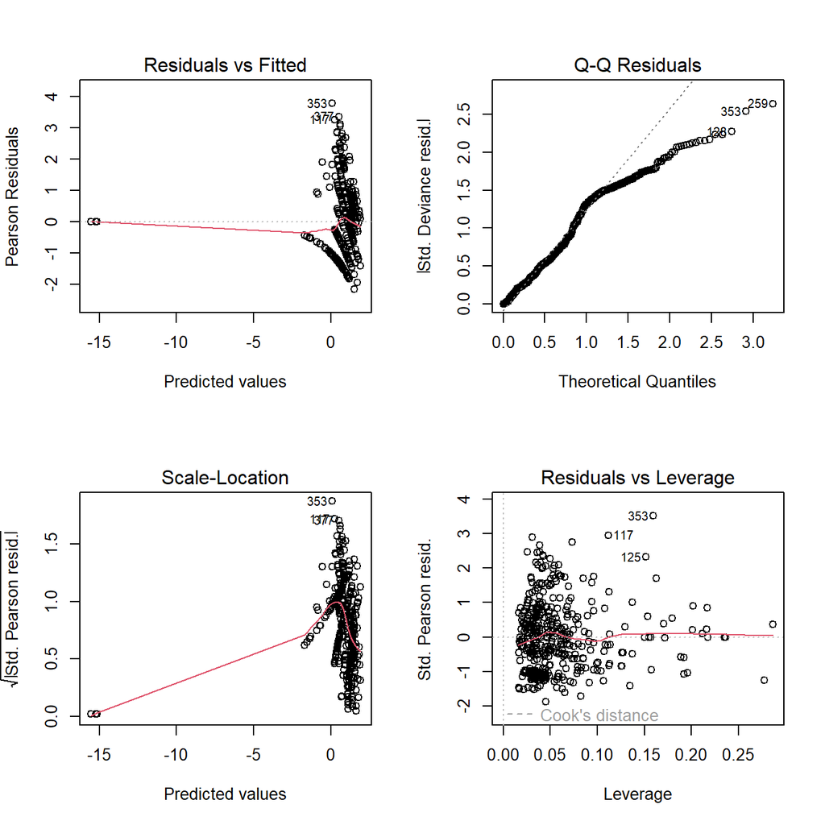

```r
par(mfrow=c(2,2))
plot(modelo)
```

```
## Half-normal plot with simulated envelope generated assuming the residuals are
##         normally distributed under the null hypothesis.
```

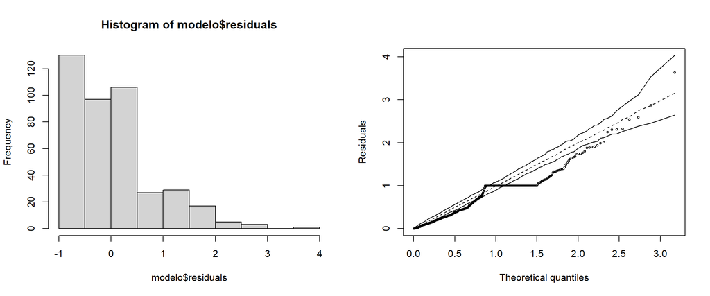

```r
par(mfrow = c(1,2))
hist(modelo$residuals)
hnp::hnp(modelo$residuals)
```

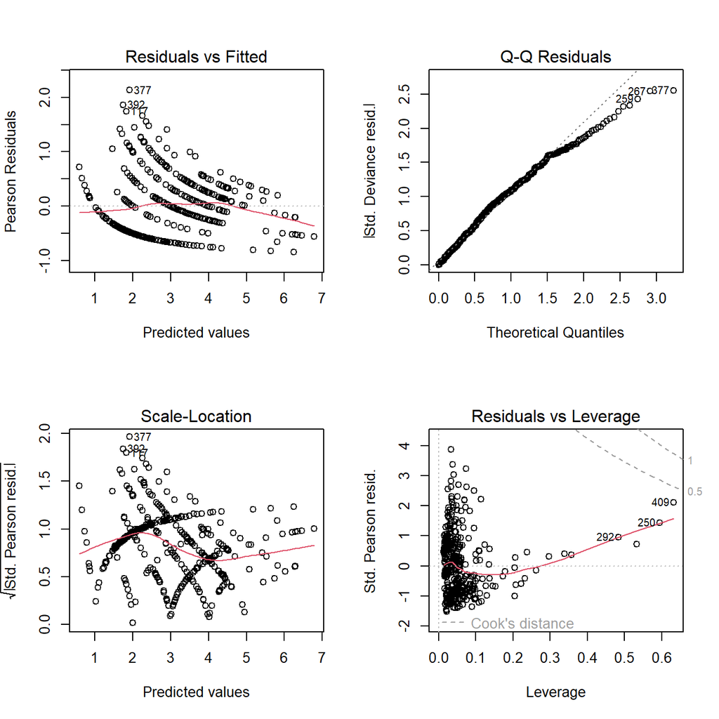

```r
df_2 <- df
df_2$FatScore <- ifelse(df_2$FatScore == 0, 1, df_2$FatScore)

# Ajustando um modelo de regressão geométrica com ligação exponencial
modelo <- glm(FatScore ~ BodyMass + Heterophils + Eosinophils + Monocytes + Basophils + Species, data = df_2, family = Gamma(link = "identity"))

par(mfrow=c(2,2))
plot(modelo)
```

```
## Half-normal plot with simulated envelope generated assuming the residuals are
##         normally distributed under the null hypothesis.
```

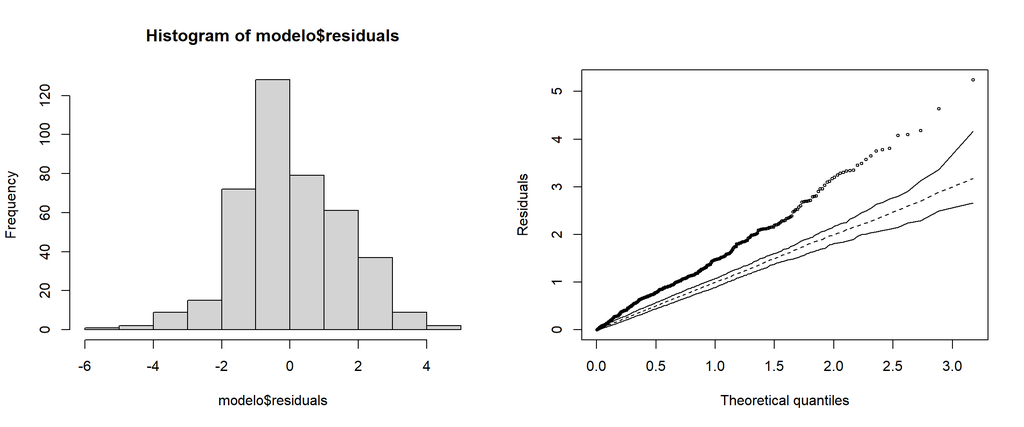

```r
par(mfrow = c(1,2))
hist(modelo$residuals)
hnp::hnp(modelo$residuals)
```

### Multinomial

```r
modelo <- multinom(FatScore ~ BodyMass + Heterophils + Eosinophils + Monocytes + Basophils, data = df)
modelo
```

```
## Call:
## multinom(formula = FatScore ~ BodyMass + Heterophils + Eosinophils +
##     Monocytes + Basophils, data = df)
##
## Coefficients:
##   (Intercept)     BodyMass  Heterophils Eosinophils  Monocytes    Basophils
## 1 -1.00667909 -0.005714961  0.016266677  0.02150115 -0.2566041  0.076371153
## 2  0.86396028 -0.009142727 -0.014666886 -0.17267997 -0.1156363 -0.073548815
## 3  1.29210417 -0.015710609  0.010695068 -0.10229008 -0.2918322  0.026609259
## 4  0.32745777 -0.018566169  0.014656232 -0.02108064 -0.1037115  0.007073102
## 5  0.47933516 -0.011369629  0.008305739 -0.03084314 -0.3336778  0.085617728
## 6 -0.06571278 -0.016445989 -0.003053029 -0.01930078 -0.2292302  0.080204291
## 7 -3.50842630 -0.006967258  0.035675766 -0.01502572 -0.2526053  0.165797004
##
## Residual Deviance: 1476.941
## AIC: 1560.941
```

```r
#par(mfrow=c(2,2))
#plot(modelo)
```

```
## Half-normal plot with simulated envelope generated assuming the residuals are
##         normally distributed under the null hypothesis.
```

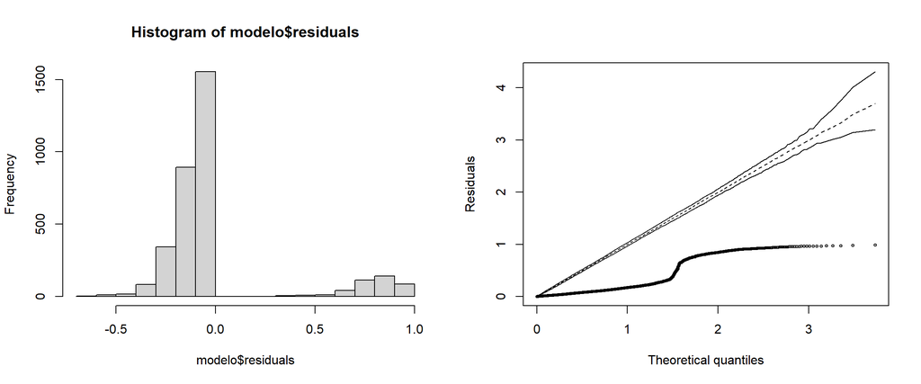

```r
par(mfrow = c(1,2))
hist(modelo$residuals)
hnp::hnp(modelo$residuals)
```

**Como esperado, será necessário dividir a base em subsets por gênero, para realizar a análise de regressão.**

### **Vamos gerar um subset para cada gênero e realizar a análise de regressão**

### Filtrando df de acordo com o genero

```r
head(df)
```

```
##              Species FatScore BodyMass Heterophils Lymphocytes Eosinophils
## 1 Actitis hypoleucos        5       56          64          19           5
## 2 Actitis hypoleucos        1       44          60          34           0
## 3 Actitis hypoleucos        2       46          63          28           5
## 4 Actitis hypoleucos        3       47           2          87           4
## 5 Actitis hypoleucos        3       44          68          24           6
## 6 Actitis hypoleucos        5       45          42          45           6
##   Monocytes Basophils HLRatio  Genero
## 1         0        12    3.37 Actitis
## 2         1         5    1.76 Actitis
## 3         0         4    2.25 Actitis
## 4         2         5    0.02 Actitis
## 5         0         2    2.83 Actitis
## 6         3         4    0.93 Actitis
```

```r
table(df$Genero)
```

```
##
##     Actitis    Arenaria    Calidris  Charadrius    Limicola      Limosa
##          22          32         117          62          11           9
## Philomachus   Pluvialis      Tringa    Vanellus
##          36           5         114           7
```

```r
df_actitis <- subset(df,df$Genero=="Actitis")
head(df_actitis)
```

```
##              Species FatScore BodyMass Heterophils Lymphocytes Eosinophils
## 1 Actitis hypoleucos        5       56          64          19           5
## 2 Actitis hypoleucos        1       44          60          34           0
## 3 Actitis hypoleucos        2       46          63          28           5
## 4 Actitis hypoleucos        3       47           2          87           4
## 5 Actitis hypoleucos        3       44          68          24           6
## 6 Actitis hypoleucos        5       45          42          45           6
##   Monocytes Basophils HLRatio  Genero
## 1         0        12    3.37 Actitis
## 2         1         5    1.76 Actitis
## 3         0         4    2.25 Actitis
## 4         2         5    0.02 Actitis
## 5         0         2    2.83 Actitis
## 6         3         4    0.93 Actitis
```

```r
df_arenaria <- subset(df,df$Genero=="Arenaria")
head(df_arenaria)
```

```
##               Species FatScore BodyMass Heterophils Lymphocytes Eosinophils
## 23 Arenaria interpres        5       95          22          61           0
## 24 Arenaria interpres        5       94          50          45           2
## 25 Arenaria interpres        4       91          30          62           1
## 26 Arenaria interpres        0       86          24          73           0
## 27 Arenaria interpres        0       81          26          63           3
## 28 Arenaria interpres        0       73          42          53           0
##    Monocytes Basophils HLRatio   Genero
## 23         0        17    0.36 Arenaria
## 24         1         2    1.11 Arenaria
## 25         1         6    0.48 Arenaria
## 26         3         0    0.33 Arenaria
## 27         3         5    0.41 Arenaria
## 28         3         2    0.79 Arenaria
```

```r
df_calidris <- subset(df,df$Genero=="Calidris")
head(df_calidris)
```

```
##            Species FatScore BodyMass Heterophils Lymphocytes Eosinophils
## 55 Calidris alpina        0       39          47          31           1
## 56 Calidris alpina        0       42          44          44           1
## 57 Calidris alpina        3       50          16          76           1
## 58 Calidris alpina        1       47          47          46           3
## 59 Calidris alpina        6       54          23          68           0
## 60 Calidris alpina        3       43          85           7           2
##    Monocytes Basophils HLRatio   Genero
## 55         2        19    1.52 Calidris
## 56         0        11    1.00 Calidris
## 57         0         7    0.21 Calidris
## 58         0         4    1.02 Calidris
## 59         0         9    0.34 Calidris
## 60         2         4   12.14 Calidris
```

```r
df_charadrius <- subset(df,df$Genero=="Charadrius")
head(df_charadrius)
```

```
##               Species FatScore BodyMass Heterophils Lymphocytes Eosinophils
## 172 Charadrius dubius        0       31          41          45          11
## 173 Charadrius dubius        0       29          55          36           4
## 174 Charadrius dubius        4       35          25          57          14
## 175 Charadrius dubius        1       33          55          37           0
## 176 Charadrius dubius        5       35          22          56          18
## 177 Charadrius dubius        5       45          15          60          22
##     Monocytes Basophils HLRatio     Genero
## 172         1         2    0.91 Charadrius
## 173         1         4    1.53 Charadrius
## 174         0         4    0.44 Charadrius
## 175         0         8    1.49 Charadrius
## 176         1         3    0.39 Charadrius
## 177         0         3    0.25 Charadrius
```

```r
df_limicola <- subset(df,df$Genero=="Limicola")
head(df_limicola)
```

```
##                  Species FatScore BodyMass Heterophils Lymphocytes Eosinophils
## 234 Limicola falcinellus        2       30          30          60           3
## 235 Limicola falcinellus        1       30          56          38           6
## 236 Limicola falcinellus        1       25          64          33           1
## 237 Limicola falcinellus        5       32          40          53           2
## 238 Limicola falcinellus        4       34          19          74           5
## 239 Limicola falcinellus        5       30          77          20           1
##     Monocytes Basophils HLRatio   Genero
## 234         3         4    0.50 Limicola
## 235         0         0    1.47 Limicola
## 236         1         1    1.94 Limicola
## 237         2         3    0.75 Limicola
## 238         2         0    0.26 Limicola
## 239         1         1    3.85 Limicola
```

```r
df_limosa <- subset(df,df$Genero=="Limosa")
head(df_limosa)
```

```
##              Species FatScore BodyMass Heterophils Lymphocytes Eosinophils
## 245 Limosa lapponica        0      225          35          55           7
## 246 Limosa lapponica        2      177          30          59           5
## 247 Limosa lapponica        3      215          13          83           3
## 248 Limosa lapponica        0      192          55          28          11
## 249 Limosa lapponica        0      220           5          79           7
## 250 Limosa lapponica        0      162          49          42           1
##     Monocytes Basophils HLRatio Genero
## 245         1         2    0.64 Limosa
## 246         1         5    0.51 Limosa
## 247         1         0    0.16 Limosa
## 248         6         0    1.96 Limosa
## 249         8         1    0.06 Limosa
## 250         6         2    1.17 Limosa
```

```r
df_philomachus <- subset(df,df$Genero=="Philomachus")
head(df_philomachus)
```

```
##                Species FatScore BodyMass Heterophils Lymphocytes Eosinophils
## 254 Philomachus pugnax        3      157          39          52           1
## 255 Philomachus pugnax        2      146          25          66           5
## 256 Philomachus pugnax        3      166          33          61           1
## 257 Philomachus pugnax        5      157          28          69           1
## 258 Philomachus pugnax        5      146          47          41           4
## 259 Philomachus pugnax        0      145          46          50           2
##     Monocytes Basophils HLRatio      Genero
## 254         0         8    0.75 Philomachus
## 255         0         4    0.38 Philomachus
## 256         0         5    0.54 Philomachus
## 257         0         2    0.41 Philomachus
## 258         3         5    1.15 Philomachus
## 259         0         2    0.92 Philomachus
```

### **Gênero Actitis** - 1° Modelo - GLM

- Sem incluir as variáveis “Lymphocytis” e “HLRatio” na criação do modelo

```r
modelo_a1 <- glm(FatScore ~ BodyMass + Heterophils + Eosinophils + Monocytes + Basophils , data = df_actitis)
modelo_a1
```

```
##
## Call:  glm(formula = FatScore ~ BodyMass + Heterophils + Eosinophils +
##     Monocytes + Basophils, data = df_actitis)
##
## Coefficients:
## (Intercept)     BodyMass  Heterophils  Eosinophils    Monocytes    Basophils
##    -3.78245      0.14810     -0.00640      0.05349      0.22130      0.06546
##
## Degrees of Freedom: 21 Total (i.e. Null);  16 Residual
## Null Deviance:       49.86
## Residual Deviance: 17.65     AIC: 71.59
```

As variáveis “Lymphocytis” e “HLRatio” não foram incluídas no modelo devido menor relação com a variável resposta.

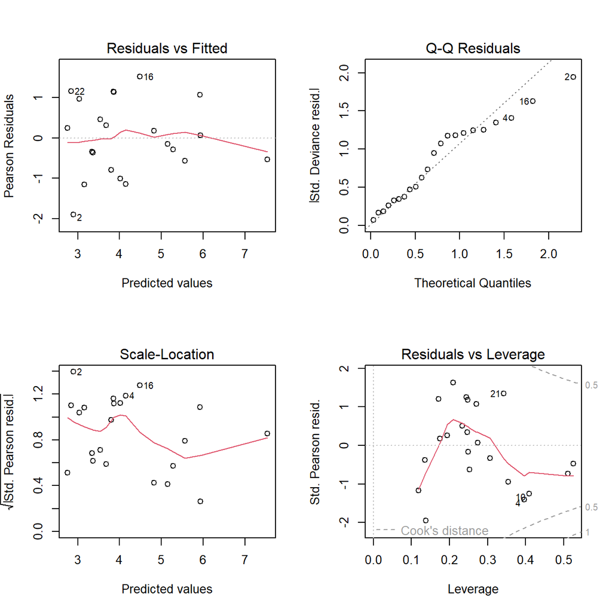

```r
par(mfrow = c(2,2))
plot(modelo_a1)
```

#### Resíduos

```
## Half-normal plot with simulated envelope generated assuming the residuals are
##         normally distributed under the null hypothesis.
```

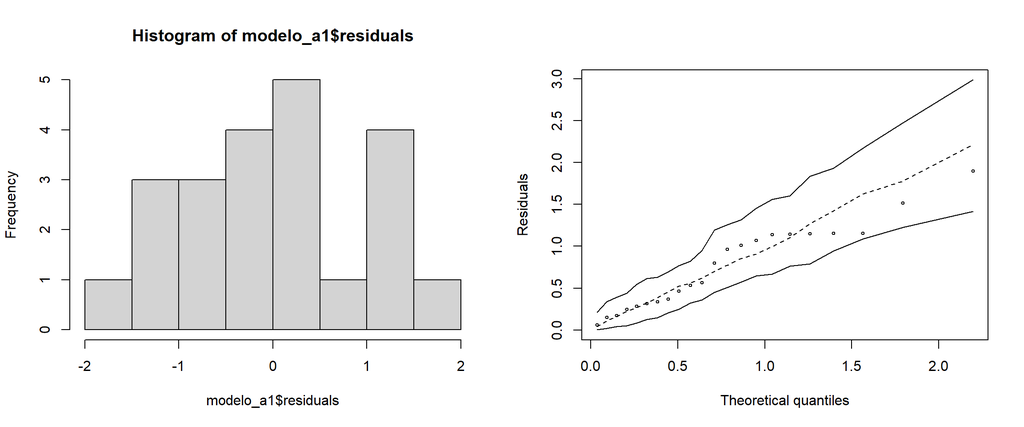

```r
par(mfrow = c(1,2))
hist(modelo_a1$residuals)
hnp::hnp(modelo_a1$residuals)
```

### **Gênero Actitis** - 2° Modelo - GLM

- Sem incluir as variáveis “Lymphocytis” e “Heterophils” na criação do modelo

```r
modelo_a2 <- glm(FatScore ~ BodyMass + HLRatio + Eosinophils + Monocytes + Basophils, data = df_actitis)
modelo_a2
```

```
##
## Call:  glm(formula = FatScore ~ BodyMass + HLRatio + Eosinophils + Monocytes +
##     Basophils, data = df_actitis)
##
## Coefficients:
## (Intercept)     BodyMass      HLRatio  Eosinophils    Monocytes    Basophils
##    -4.04977      0.14628     -0.03258      0.06080      0.25938      0.07103
##
## Degrees of Freedom: 21 Total (i.e. Null);  16 Residual
## Null Deviance:       49.86
## Residual Deviance: 17.84     AIC: 71.83
```

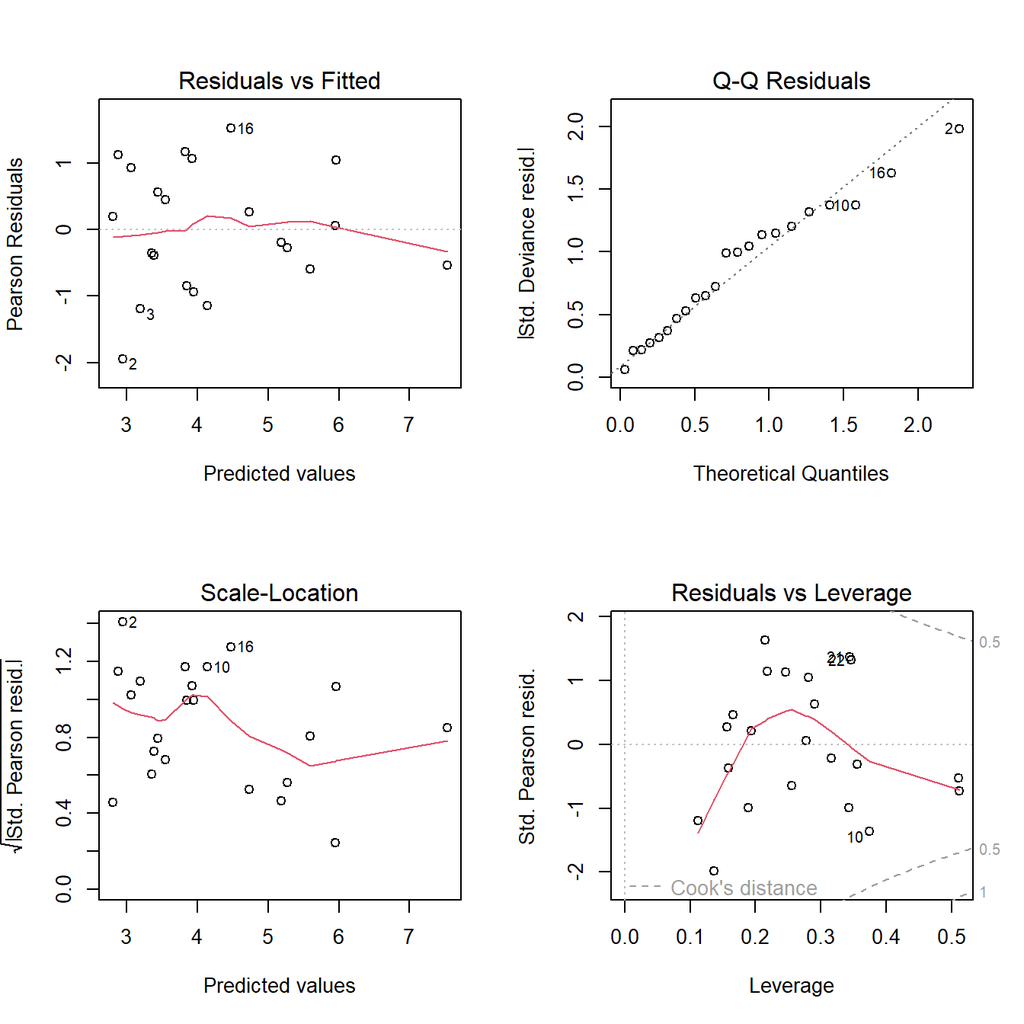

```r
par(mfrow = c(2,2))
plot(modelo_a2)
```

#### Resíduos

```
## Half-normal plot with simulated envelope generated assuming the residuals are
##         normally distributed under the null hypothesis.
```

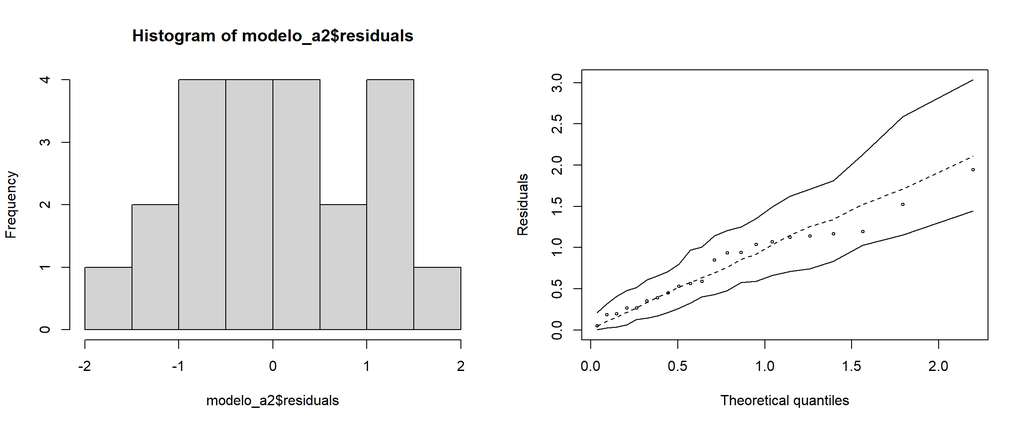

```r
par(mfrow = c(1,2))
hist(modelo_a2$residuals)
hnp::hnp(modelo_a2$residuals)
```

### **Comparação AIC**

```r
AIC(modelo_a1,modelo_a2)
```

```
##           df      AIC
## modelo_a1  7 71.58834
## modelo_a2  7 71.82568
```

### **Gênero Limosa** - 1° Modelo - GLM

- Sem incluir as variáveis “Lymphocytis” e “HLRatio” na criação do modelo

```r
modelo_limosa_1 <- glm(FatScore ~ BodyMass + Heterophils + Eosinophils + Monocytes + Basophils , data = df_limosa)
modelo_limosa_1
```

```
##
## Call:  glm(formula = FatScore ~ BodyMass + Heterophils + Eosinophils +
##     Monocytes + Basophils, data = df_limosa)
##
## Coefficients:
## (Intercept)     BodyMass  Heterophils  Eosinophils    Monocytes    Basophils
##    2.048836     0.002445    -0.029073    -0.089477    -0.143367     0.012406
##
## Degrees of Freedom: 8 Total (i.e. Null);  3 Residual
## Null Deviance:       11.56
## Residual Deviance: 5.257     AIC: 34.7
```

As variáveis “Lymphocytis” e “HLRatio” não foram incluídas no modelo devido menor relação com a variável resposta.

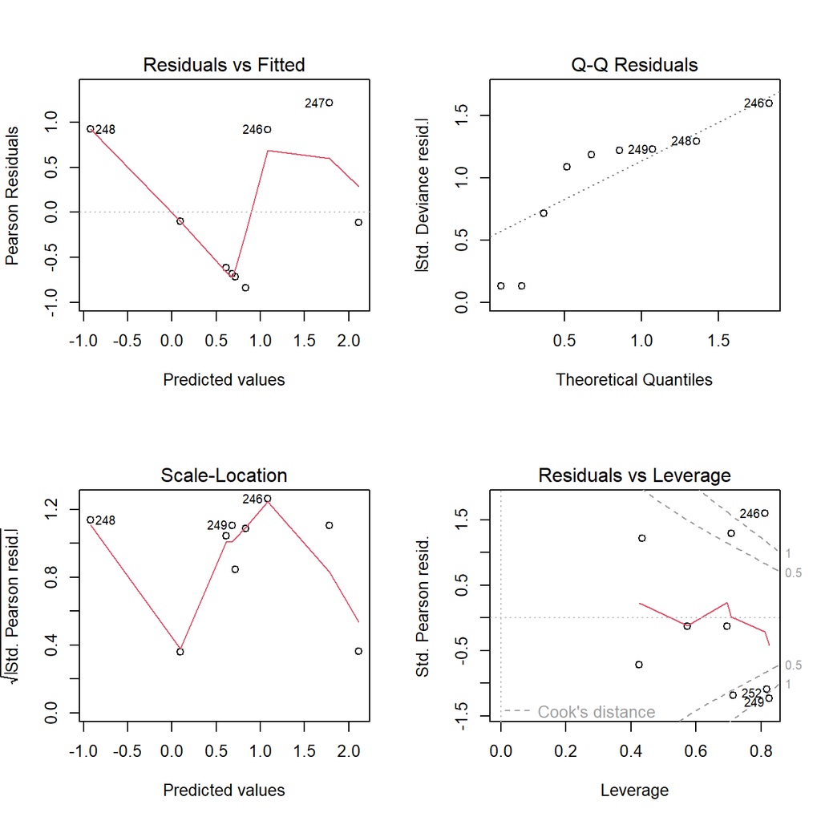

```r
par(mfrow = c(2,2))
plot(modelo_limosa_1)
```

#### Resíduos

```
## Half-normal plot with simulated envelope generated assuming the residuals are
##         normally distributed under the null hypothesis.
```

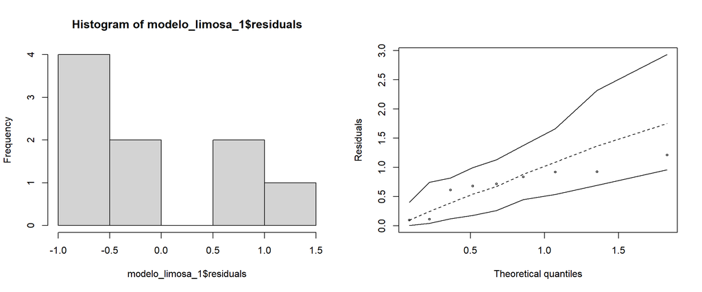

```r
par(mfrow = c(1,2))
hist(modelo_limosa_1$residuals)
hnp::hnp(modelo_limosa_1$residuals)
```

### **Gênero Limosa** - 2° Modelo - GLM

- Sem incluir as variáveis “Lymphocytis” e “Heterophils” na criação do modelo

```r
modelo_limosa_2 <- glm(FatScore ~ BodyMass + HLRatio + Eosinophils + Monocytes + Basophils, data = df_limosa)
modelo_limosa_2
```

```
##
## Call:  glm(formula = FatScore ~ BodyMass + HLRatio + Eosinophils + Monocytes +
##     Basophils, data = df_limosa)
##
## Coefficients:
## (Intercept)     BodyMass      HLRatio  Eosinophils    Monocytes    Basophils
##    0.441523     0.008686    -0.509419    -0.103210    -0.134544    -0.040855
##
## Degrees of Freedom: 8 Total (i.e. Null);  3 Residual
## Null Deviance:       11.56
## Residual Deviance: 6.232     AIC: 36.23
```

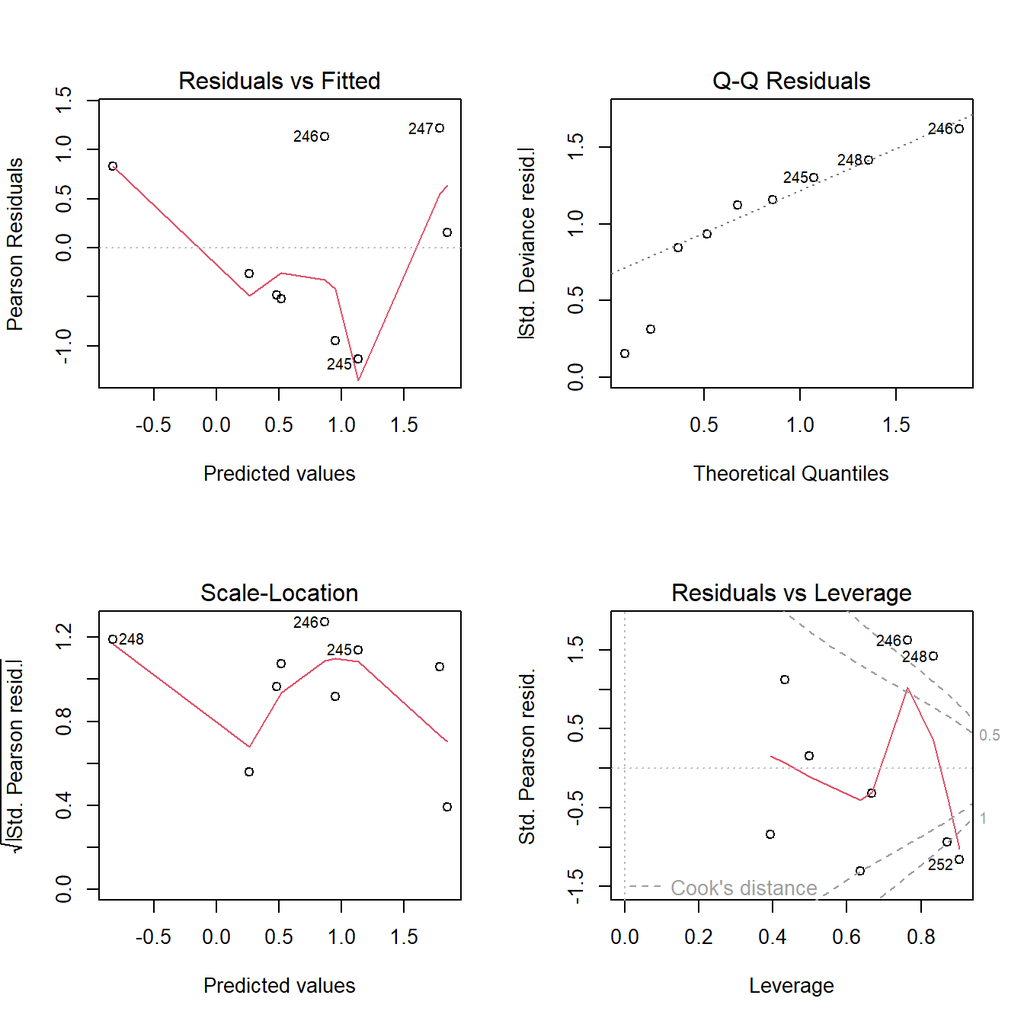

```r
par(mfrow = c(2,2))
plot(modelo_limosa_2)
```

#### Resíduos

```
## Half-normal plot with simulated envelope generated assuming the residuals are
##         normally distributed under the null hypothesis.
```

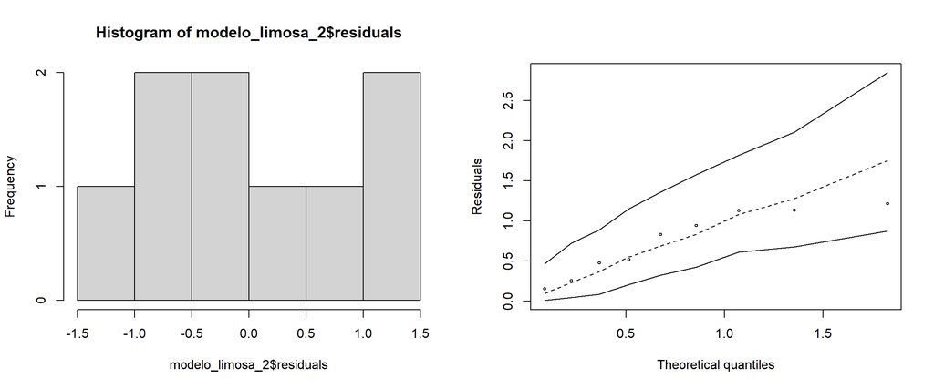

```r
par(mfrow = c(1,2))
hist(modelo_limosa_2$residuals)
hnp::hnp(modelo_limosa_2$residuals)
```

### **Comparação AIC**

```r
AIC(modelo_limosa_1,modelo_limosa_2)
```

```
##                 df      AIC
## modelo_limosa_1  7 34.70235
## modelo_limosa_2  7 36.23383
```